# Support Vector Machine Modeling of Transcription Factor Binding Sites

Brady Nifong, Mike Nodzenski, Fan Zhou

## Introduction

### Background

- Despite rapid improvements in high throughput sequencing technologies, the functional significance of much of the human genome remains unclear.
- While protein coding regions have been well characterized, the majority of bases do not fall into this category.
- The ongoing Encyclopedia of DNA Elements (ENCODE) Project (1) seeks to address this issue.
- A key goal of the project is to more fully describe the mechanisms of gene transcription.
  - Variety of techniques used including but not limited to: CHIP-seq (transcription factor binding), DNAse-seq (open chromatin)
  - Our project focuses on CHIP-seq data from ENCODE

### Motivating Study

> Arvey A, Agius P, Noble WS, Leslie C. Sequence and chromatin determinants of cell-type-specific transcription factor binding. Genome Res. 2012 Sep;22(9):1723-34.
- The aim of this study was to predict cell type specific transcription factor (TF) binding using publicly available ENCODE data.
- Traditionally, this is done using motif finding algorithms to identify high affinity sequence for a particular protein.
- Arvey et al. argued support vector machine modeling (SVM) of TF binding more accurately predicts binding sites than traditional approaches.
- They analyzed TF factor binding data for 286 CHIP-seq experiments of 67 transcriptional regulators using Kmer SVM and three motif finding approaches: MDScan, cERMIT, WeederK1.
  - Key feature of the Kmer SVM: string kernel developed by the authors specifically for these types of sequence data.
- Ultimately, they found the Kmer SVM approach more accurately predicted TF binding than the motif finding approaches, as assessed by area on the curve.
- They further investigated whether open chromatin and histone modifications played a role in cell specific TF binding.
  - Found that open chromatin was a strong predictor of cell-specific binding.

### Our Aims

- Project of the scope of Arvey et al. (analysis of 286 experiments) was clearly not possible.
- Moreover, the motif finding approaches they used do not appear to be available through Bioconductor. It’s also not clear whether those algorithms can run on personal computers.
- We chose to address a simplified question: Can we use SVM to accurately predict transcription factor binding in a subset of the cell lines and proteins investigated by Arvey?

## Methods

### Experiment Selection

- Queried AnnotationHub for CHIP-seq data the following proteins from Arvey et al.: PAX5, REST, USF1, MAX, JUND, YY1, GABPA
- Our goal was to choose proteins with experimental data across multiple cell lines.
- Based on available data, we selected the following:
- Proteins:
  - JUND
  - MAX
  - USF1
- Cell Lines:
  - H1hesc
  - Hepg2
  - GM12878
  - K562

### Data Processing

Following the methods of Arvey et al. for all cell line/protein combinations:

1. Selected the top 1000 CHIP-seq peaks by signal value.
2. Extracted sequence for 100 bp region from each selected peak as a positive binding examples.
3. Used flanking 100-bp regions sampled 200 bp away as non-binding examples.

### Support Vector Machine Modeling

- Initially ran models individually on specific cell line/protein combinations using SVM as implemented in the Kebabs Bioconductor package.
  - Used DNA sequence to predict binding vs. non-binding status.
  - Sampled 70% of extracted sequence for training data.
  - Used the remaining 30% of data for testing.
  - Kernel used by Arvey et al. (to our knowledge) not available through Bioconductor or CRAN. Instead used mismatch kernel introduced by the senior author of Arvey et al.
  - Set parameters k = 8, m = 2, per Arvey et al. methods.
- Also ran models for protein binding pooling data across cell lines using the same approach (although not primarily interested in these results)

### Assessing SVM Accuracy

- Accuracy for all models is reported only for testing data
1. Comparison to known transcription factor motifs
- Pulled known protein binding motifs from the JASPAR database.
- Extracted the kmer with the highest feature weight from the SVM (the most predictive kmer).
- Compared to known motif.
2. Area under the curve
- This was a primary means of assessing model accuracy in Arvey et al.
- Not as immediately interpretable as comparison to known motifs.
- Nevertheless, a useful secondary indicator of predictive ability.

## Results

### Comparison to JASPAR Motifs

- The following figures compare the JASPAR Motifs to the most predicivtive kmer (determined by having the largest absolute feature weight in the svm)
- Though they are relatively close, we see that the svm models USF1 the best, and had the hardest time modeling JUND.

#### JUND:

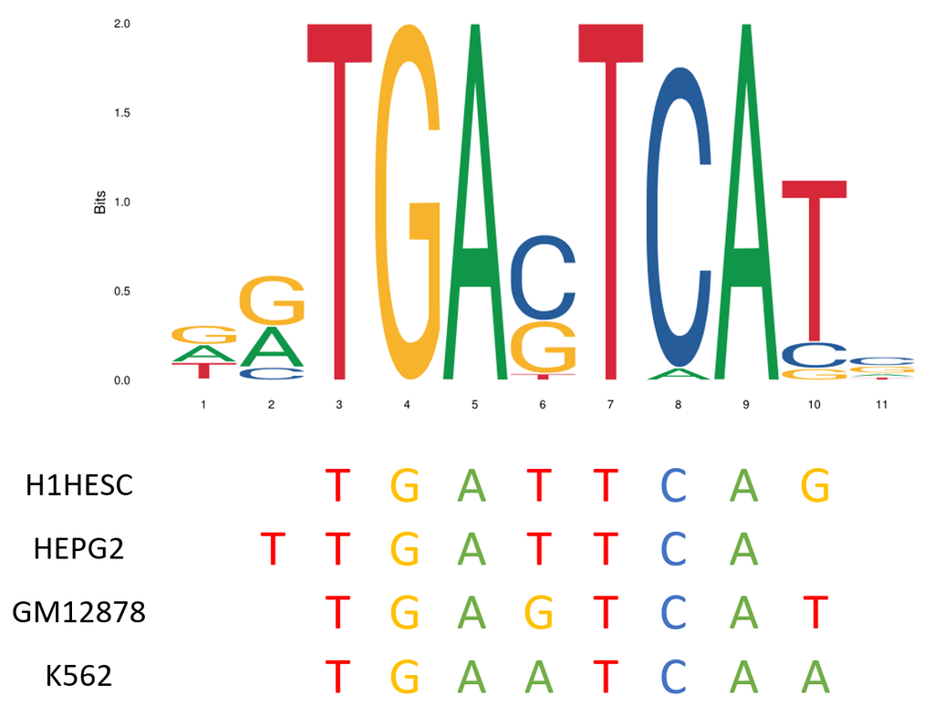

#### MAX

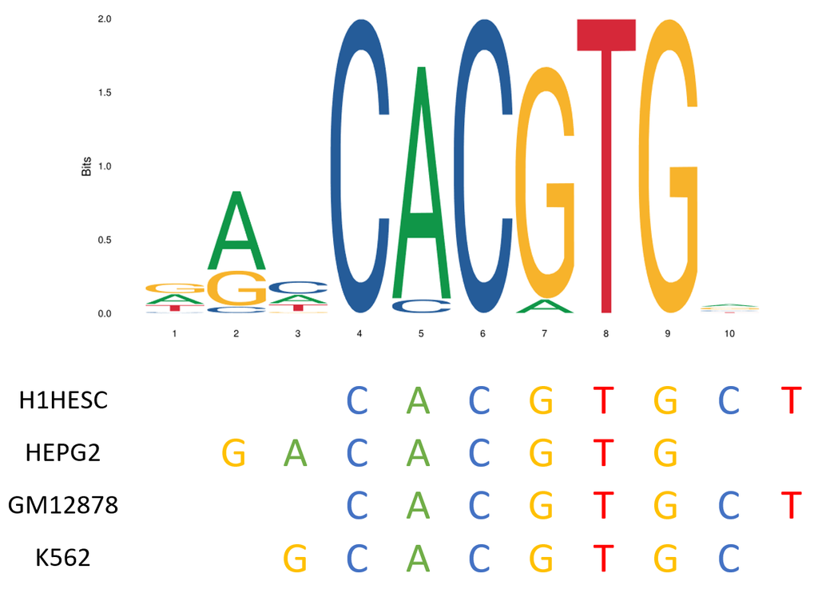

#### USF1

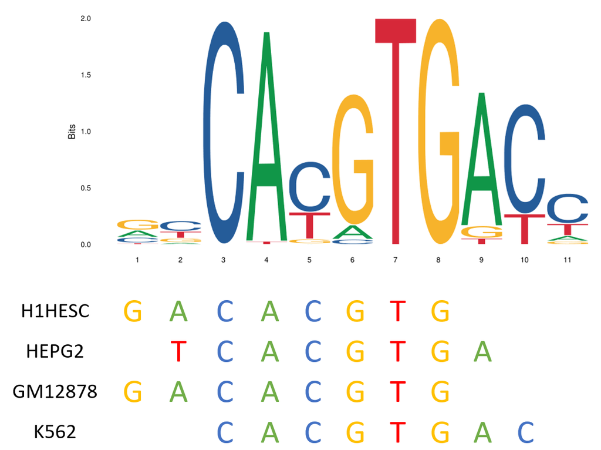

### Examination of Feature Weights

- The following three plots display the distribution of feature weights for each svm that was fitted.
- All the histograms are unimodal and centered around zero.
- The histograms show that a majority of the features provide little information towards predicting binding sites.

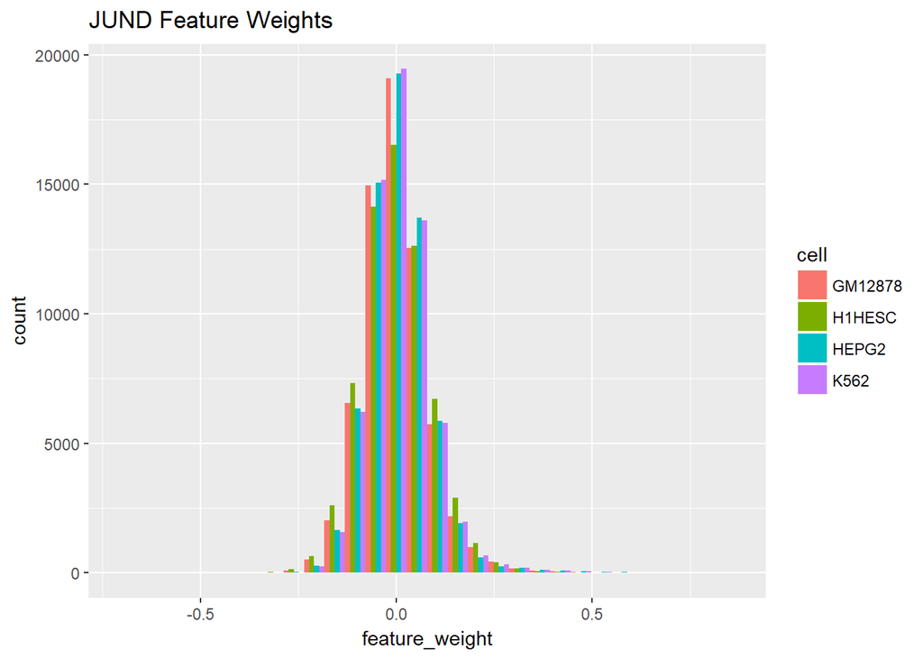

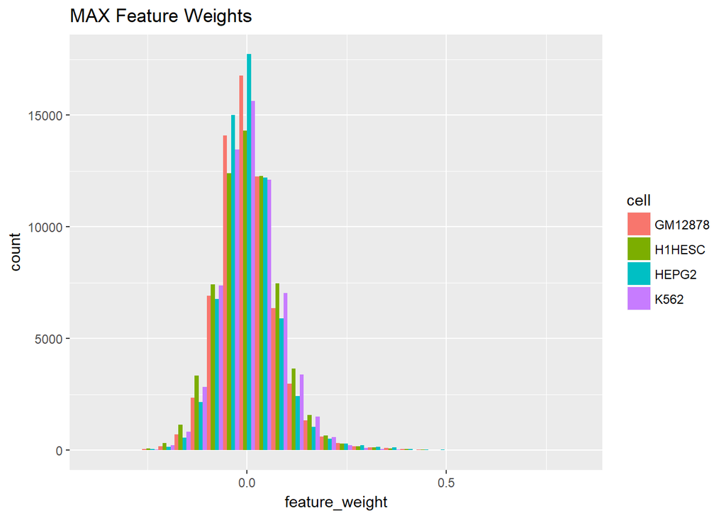

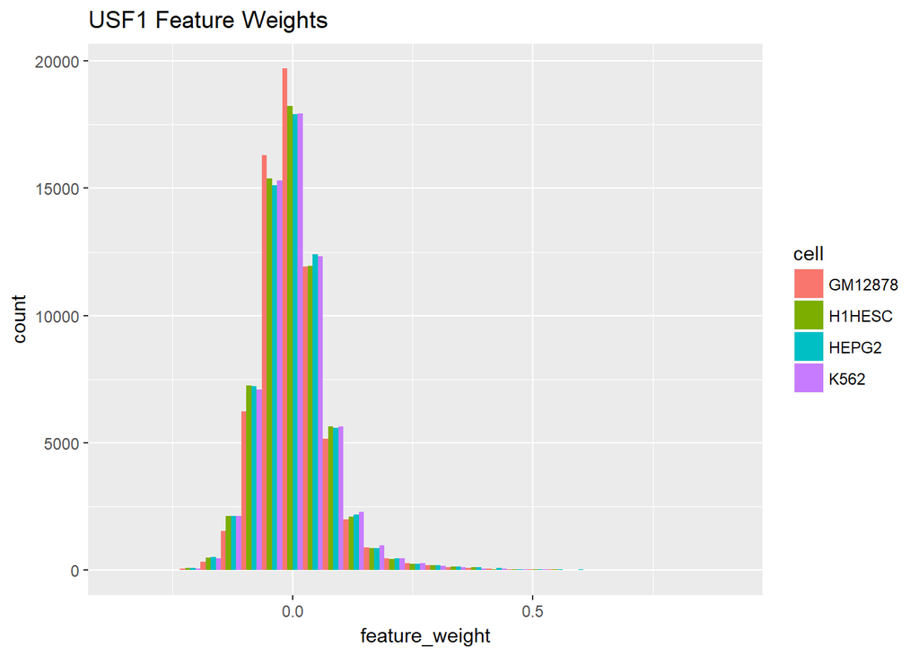

### Area Under the Curve (AUC)

- We plotted the sensitivity vs false positive rate and gave the AUC for each cell specific model, as well as pooling the data across cell-lines.

#### Cell specific models:

- In general, it appears that USF1 has the best sensitivity vs false positive plot as well as the best AUC for each cell line.
  - The AUC that is best between JUND and MAX varies by cell-line.
  - Similarly, the sensitivity vs false positive rate plot that is best between JUND and MAX varies by cell-line.

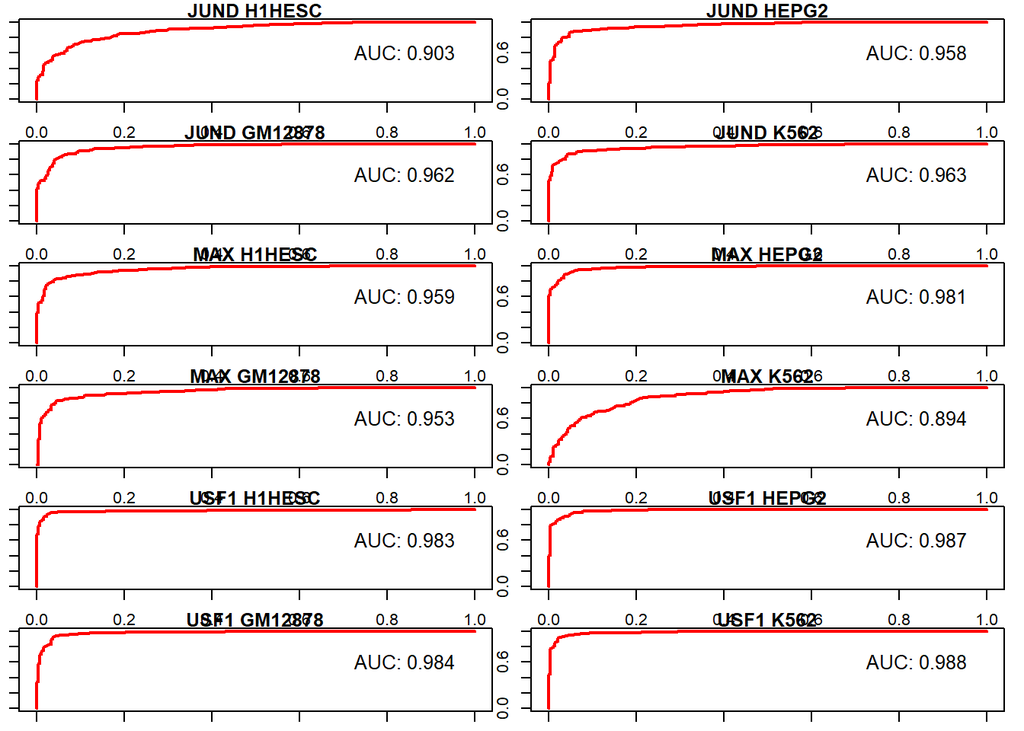

#### Models pooling data across cell-lines

- When pooling the data across cell-lines we can see that once again USF1 has the best sensitivity vs false positive rate plot, as well as the best AUC.
- The AUC for MAX and JUND seems to be approximately the same across cell-lines, while the sensitivity vs false positive rate plot for MAX seems *slightly* better than the plot for JUND.

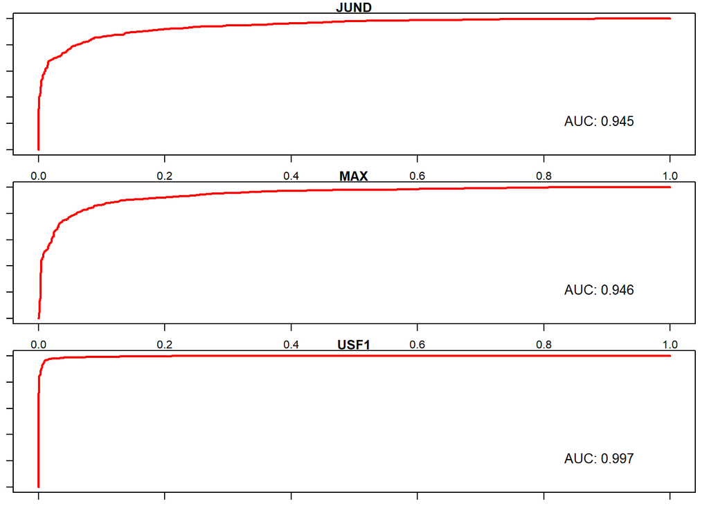

## References

1. The ENCODE Project Consortium. An Integrated Encyclopedia of DNA Elements in the Human Genome. Nature. 2012;489(7414):57-74. doi:10.1038/nature11247.